```python
#import lib
import numpy as np
import pandas as pd
import matplotlib.pyplot as plt
import seaborn as sb
from sklearn.impute import SimpleImputer
import datetime
import time
import os
import requests
```

```python
#upload data file
foldername = 'GoBike'
if not os.path.exists(foldername):
    os.makedirs(foldername)

url = 'https://video.udacity-data.com/topher/2020/October/5f91cf38_201902-fordgobike-tripdata/201902-fordgobike-tripdata.csv'
response = requests.get(url, allow_redirects=True)
with open (os.path.join(foldername,url.split('/')[-1]),mode='wb') as file:
    file.write(response.content)

df = pd.read_csv('GoBike/201902-fordgobike-tripdata.csv')
```

# Checking the data

```python
#show first 5 lines
df.head()
```

|  | duration_sec | start_time | end_time | start_station_id | start_station_name | start_station_latitude | start_station_longitude | end_station_id | end_station_name | end_station_latitude | end_station_longitude | bike_id | user_type | member_birth_year | member_gender | bike_share_for_all_trip |
| --- | --- | --- | --- | --- | --- | --- | --- | --- | --- | --- | --- | --- | --- | --- | --- | --- |
| 0 | 52185 | 2019-02-28 17:32:10.1450 | 2019-03-01 08:01:55.9750 | 21.0 | Montgomery St BART Station (Market St at 2nd St) | 37.789625 | -122.400811 | 13.0 | Commercial St at Montgomery St | 37.794231 | -122.402923 | 4902 | Customer | 1984.0 | Male | No |
| 1 | 42521 | 2019-02-28 18:53:21.7890 | 2019-03-01 06:42:03.0560 | 23.0 | The Embarcadero at Steuart St | 37.791464 | -122.391034 | 81.0 | Berry St at 4th St | 37.775880 | -122.393170 | 2535 | Customer | NaN | NaN | No |
| 2 | 61854 | 2019-02-28 12:13:13.2180 | 2019-03-01 05:24:08.1460 | 86.0 | Market St at Dolores St | 37.769305 | -122.426826 | 3.0 | Powell St BART Station (Market St at 4th St) | 37.786375 | -122.404904 | 5905 | Customer | 1972.0 | Male | No |
| 3 | 36490 | 2019-02-28 17:54:26.0100 | 2019-03-01 04:02:36.8420 | 375.0 | Grove St at Masonic Ave | 37.774836 | -122.446546 | 70.0 | Central Ave at Fell St | 37.773311 | -122.444293 | 6638 | Subscriber | 1989.0 | Other | No |
| 4 | 1585 | 2019-02-28 23:54:18.5490 | 2019-03-01 00:20:44.0740 | 7.0 | Frank H Ogawa Plaza | 37.804562 | -122.271738 | 222.0 | 10th Ave at E 15th St | 37.792714 | -122.248780 | 4898 | Subscriber | 1974.0 | Male | Yes |

```python
#check info for types and Nulls
df.info()
```

```
<class 'pandas.core.frame.DataFrame'>
RangeIndex: 183412 entries, 0 to 183411
Data columns (total 16 columns):
 #   Column                   Non-Null Count   Dtype
---  ------                   --------------   -----
 0   duration_sec             183412 non-null  int64
 1   start_time               183412 non-null  object
 2   end_time                 183412 non-null  object
 3   start_station_id         183215 non-null  float64
 4   start_station_name       183215 non-null  object
 5   start_station_latitude   183412 non-null  float64
 6   start_station_longitude  183412 non-null  float64
 7   end_station_id           183215 non-null  float64
 8   end_station_name         183215 non-null  object
 9   end_station_latitude     183412 non-null  float64
 10  end_station_longitude    183412 non-null  float64
 11  bike_id                  183412 non-null  int64
 12  user_type                183412 non-null  object
 13  member_birth_year        175147 non-null  float64
 14  member_gender            175147 non-null  object
 15  bike_share_for_all_trip  183412 non-null  object
dtypes: float64(7), int64(2), object(7)
memory usage: 22.4+ MB
```

```python
#check numeric content
df.describe()
```

|  | duration_sec | start_station_id | start_station_latitude | start_station_longitude | end_station_id | end_station_latitude | end_station_longitude | bike_id | member_birth_year |
| --- | --- | --- | --- | --- | --- | --- | --- | --- | --- |
| count | 183412.000000 | 183215.000000 | 183412.000000 | 183412.000000 | 183215.000000 | 183412.000000 | 183412.000000 | 183412.000000 | 175147.000000 |
| mean | 726.078435 | 138.590427 | 37.771223 | -122.352664 | 136.249123 | 37.771427 | -122.352250 | 4472.906375 | 1984.806437 |
| std | 1794.389780 | 111.778864 | 0.099581 | 0.117097 | 111.515131 | 0.099490 | 0.116673 | 1664.383394 | 10.116689 |
| min | 61.000000 | 3.000000 | 37.317298 | -122.453704 | 3.000000 | 37.317298 | -122.453704 | 11.000000 | 1878.000000 |
| 25% | 325.000000 | 47.000000 | 37.770083 | -122.412408 | 44.000000 | 37.770407 | -122.411726 | 3777.000000 | 1980.000000 |
| 50% | 514.000000 | 104.000000 | 37.780760 | -122.398285 | 100.000000 | 37.781010 | -122.398279 | 4958.000000 | 1987.000000 |
| 75% | 796.000000 | 239.000000 | 37.797280 | -122.286533 | 235.000000 | 37.797320 | -122.288045 | 5502.000000 | 1992.000000 |
| max | 85444.000000 | 398.000000 | 37.880222 | -121.874119 | 398.000000 | 37.880222 | -121.874119 | 6645.000000 | 2001.000000 |

```python
#check for duplicated rows
df.duplicated().sum()
```

```
0
```

# Cleaning

```python
#remove useless columns
df2 = df.drop(['start_station_id', 'start_station_latitude', 'start_station_longitude','end_station_id','end_station_latitude','end_station_longitude'], axis = 1)
```

```python
#Handling Nans
##for birthdays we can fill with mean
df2['member_birth_year'] = df2['member_birth_year'].fillna(df['member_birth_year'].mean(axis=0))
##for gender replace nan with other
df2['member_gender'] = df2['member_gender'].fillna('Other')
##for missing start and end station, drop rows with Nan
df2 = df2.dropna()
```

```python
#test for Nans
df2.isnull().sum()
```

```
duration_sec               0
start_time                 0
end_time                   0
start_station_name         0
end_station_name           0
bike_id                    0
user_type                  0
member_birth_year          0
member_gender              0
bike_share_for_all_trip    0
dtype: int64
```

```python
#add age using the birthyear
df2['member_age'] = 2020 - df2['member_birth_year']
```

```python
#Convert time-type columns
df2['start_time'] = pd.to_datetime(df2['start_time'])
df2['end_time'] = pd.to_datetime(df2['end_time'])
```

```python
#create new duration in minuties
df2['duration_min'] = df2['duration_sec'] / 60
```

# Findings

```python
#Seasonality: check count of trips over time (using start time dates)
#sort start dates
df2.sort_values(by=['start_time'], ascending = True)
```

|  | duration_sec | start_time | end_time | start_station_name | end_station_name | bike_id | user_type | member_birth_year | member_gender | bike_share_for_all_trip | member_age | duration_min |
| --- | --- | --- | --- | --- | --- | --- | --- | --- | --- | --- | --- | --- |
| 183411 | 271 | 2019-02-01 00:00:20.636 | 2019-02-01 00:04:52.058 | Spear St at Folsom St | 2nd St at Folsom St | 1057 | Subscriber | 1989.0 | Male | No | 31.0 | 4.516667 |
| 183406 | 706 | 2019-02-01 00:04:40.616 | 2019-02-01 00:16:27.080 | Jersey St at Church St | Folsom St at 9th St | 5017 | Subscriber | 1988.0 | Male | No | 32.0 | 11.766667 |
| 183407 | 480 | 2019-02-01 00:04:49.724 | 2019-02-01 00:12:50.034 | Beale St at Harrison St | Union Square (Powell St at Post St) | 4832 | Subscriber | 1996.0 | Male | No | 24.0 | 8.000000 |
| 183410 | 139 | 2019-02-01 00:05:34.360 | 2019-02-01 00:07:54.287 | San Pablo Ave at MLK Jr Way | San Pablo Ave at 27th St | 5095 | Subscriber | 1988.0 | Male | No | 32.0 | 2.316667 |
| 183408 | 313 | 2019-02-01 00:05:34.744 | 2019-02-01 00:10:48.502 | Montgomery St BART Station (Market St at 2nd St) | 3rd St at Townsend St | 4960 | Subscriber | 1984.0 | Male | No | 36.0 | 5.216667 |
| ... | ... | ... | ... | ... | ... | ... | ... | ... | ... | ... | ... | ... |
| 6 | 1147 | 2019-02-28 23:55:35.104 | 2019-03-01 00:14:42.588 | Palm St at Willow St | San Jose Diridon Station | 3803 | Subscriber | 1983.0 | Female | No | 37.0 | 19.116667 |
| 14 | 395 | 2019-02-28 23:56:26.848 | 2019-03-01 00:03:01.947 | Bancroft Way at College Ave | Channing Way at Shattuck Ave | 4786 | Subscriber | 1988.0 | Male | No | 32.0 | 6.583333 |
| 11 | 506 | 2019-02-28 23:56:55.540 | 2019-03-01 00:05:21.733 | Civic Center/UN Plaza BART Station (Market St ... | Bryant St at 2nd St | 5848 | Subscriber | 1993.0 | Male | No | 27.0 | 8.433333 |
| 10 | 458 | 2019-02-28 23:57:57.211 | 2019-03-01 00:05:35.435 | Jones St at Post St | San Francisco Public Library (Grove St at Hyde... | 5318 | Subscriber | 1996.0 | Female | Yes | 24.0 | 7.633333 |
| 15 | 208 | 2019-02-28 23:59:18.548 | 2019-03-01 00:02:47.228 | Howard St at Mary St | 8th St at Ringold St | 6361 | Subscriber | 1993.0 | Male | Yes | 27.0 | 3.466667 |

183215 rows × 12 columns

```python
#plot counts over time
#create day column
df2['days'] = df2['start_time'].dt.day
days = df2.groupby(['days']).size().reset_index(name='counts')
```

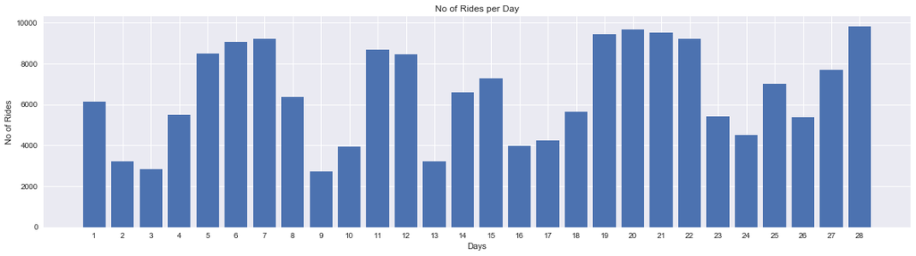

```python
#plot days with counts
plt.figure(figsize=[20, 5])
plt.style.use('seaborn')
plt.bar(days['days'],days['counts'])
plt.title('No of Rides per Day')
plt.xlabel('Days')
plt.xticks(days['days'])
plt.ylabel('No of Rides')
plt.show();
```

From the above chart showing the number of rides during the month on daily basis, there seems to be a cycling relationship that needs more investigation

```python
#check same exercise but based on weekdays
df2['start_time'] = pd.to_datetime(df['start_time'], format = '%Y-%m-%d %H:%M:%S')
df2['weekday'] = df2['start_time'].dt.day_name()
```

```python
#Create DF for weekdays
wdays = df2.groupby(['weekday']).size().reset_index(name='counts')
```

```python
#Sort weekdays
wdays['weekday'] = ['Monday', 'Tuesday','Wednesday','Thursday','Friday','Saturday','Sunday']
wdays.sort_values(by=['weekday'])
```

|  | weekday | counts |
| --- | --- | --- |
| 4 | Friday | 35176 |
| 0 | Monday | 28962 |
| 5 | Saturday | 31781 |
| 6 | Sunday | 29609 |
| 3 | Thursday | 15503 |
| 1 | Tuesday | 26807 |
| 2 | Wednesday | 15377 |

[figure not shown]

```python
#plot wdays with counts
plt.style.use('seaborn')
plt.bar(wdays['weekday'],wdays['counts'])
plt.title('No of Rides per Weekday')
plt.xlabel('Weekdays')
plt.xticks(rotation=25);
plt.ylabel('No of Rides')
plt.show();
```

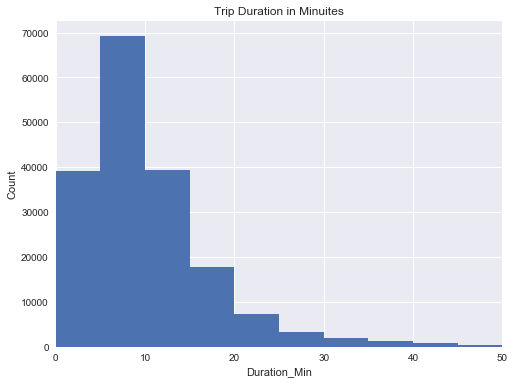

```python
#plot durations
bins=np.arange(0, df2['duration_min'].max() + 5 , 5)
plt.figure(figsize=[8, 6])
plt.hist(data = df2, x = 'duration_min',bins=bins)
plt.xlim(0,50)
plt.title('Trip Duration in Minuites')
plt.ylabel('Count');
plt.xlabel('Duration_Min');
```

```python
#Duration numerics
df2['duration_min'].describe()
```

```
count    183215.000000
mean         12.098367
std          29.917978
min           1.016667
25%           5.416667
50%           8.566667
75%          13.266667
max        1424.066667
Name: duration_min, dtype: float64
```

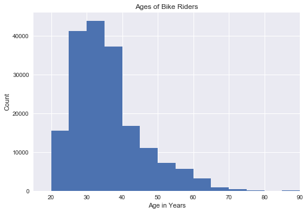

```python
#Plot ages
#some ages seem ilogical most probably for using 1900 as defalut year so limit set to 90
bins=np.arange(0, df2['member_age'].max() + 5 , 5)
plt.hist(data = df2, x = 'member_age',bins=bins)
plt.xlim(15,90)
plt.ylabel('Count');
plt.title('Ages of Bike Riders')
plt.xlabel('Age in Years');
```

```python
#Age numerics
df2['member_age'].describe()
```

```
count    183215.000000
mean         35.196716
std           9.887920
min          19.000000
25%          28.000000
50%          33.000000
75%          39.000000
max         142.000000
Name: member_age, dtype: float64
```

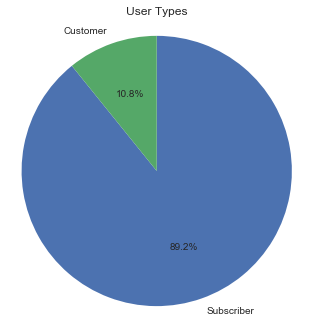

```python
#compare user_type
mem = df2['user_type'].value_counts()
plt.pie(mem, labels = mem.index, startangle = 90, counterclock = False,autopct='%1.1f%%');
plt.style.use('seaborn')
plt.title('User Types')
plt.axis('square');
```

Comparing types of riders, Subscribers exceeds the casual customers by far at almost 90% during the examined duration. This can be explained as common riders find it better to subscribe to gain more privileges for their loyalty

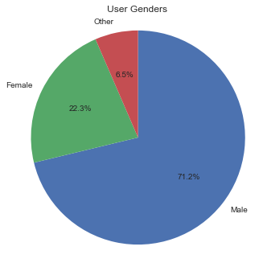

```python
#compare genders
gen = df2['member_gender'].value_counts()
plt.pie(gen, labels = gen.index, startangle = 90, counterclock = False,autopct='%1.1f%%');
plt.title('User Genders')
plt.axis('square');
```

```python
#check highest start stations
start = df2['start_station_name'].value_counts().reset_index(name='counts')
st = start[:10]
st
```

|  | index | counts |
| --- | --- | --- |
| 0 | Market St at 10th St | 3904 |
| 1 | San Francisco Caltrain Station 2 (Townsend St... | 3544 |
| 2 | Berry St at 4th St | 3052 |
| 3 | Montgomery St BART Station (Market St at 2nd St) | 2895 |
| 4 | Powell St BART Station (Market St at 4th St) | 2760 |
| 5 | San Francisco Ferry Building (Harry Bridges Pl... | 2710 |
| 6 | San Francisco Caltrain (Townsend St at 4th St) | 2703 |
| 7 | Powell St BART Station (Market St at 5th St) | 2327 |
| 8 | Howard St at Beale St | 2293 |
| 9 | Steuart St at Market St | 2283 |

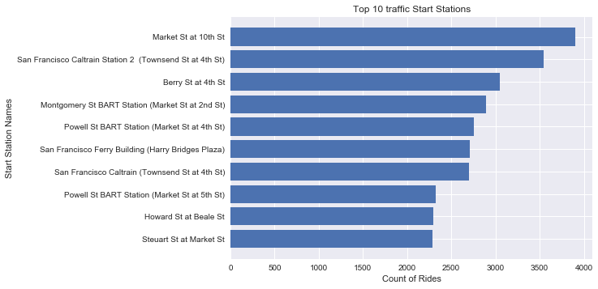

```python
#plot start station traffic
plt.barh(st['index'],st['counts'])
plt.title('Top 10 traffic Start Stations')
plt.ylabel('Start Station Names')
plt.xlabel('Count of Rides')
plt.gca().invert_yaxis()
plt.show();
```

As shown in the above chart, that busiest traffic was on 'Market St at 10th St' as the starting point of 3904 trips followed by 'San Francisco Caltrain Station 2' with 3544 trip. This info is valuable when planning the bikes availability at those hot spots to ensure that each customer can find a bike.

# Bivariate Exploration

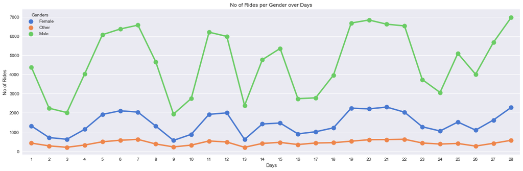

```python
#relation between gender and rides over day
##create df
dfg = df2.groupby(['member_gender', 'days']).size().reset_index(name='counts')
##Plot
plt.figure(figsize = (20, 6))
plt.style.use('seaborn')
sb.pointplot(data = dfg.sort_values(by='days'), x = 'days', y = 'counts',
             hue = 'member_gender', palette = 'muted');
plt.legend(title = 'Genders');
plt.title('No of Rides per Gender over Days');
plt.xlabel('Days');
plt.ylabel('No of Rides');
```

As shown above, Males have the highest count of rides throughout the month compared to Females

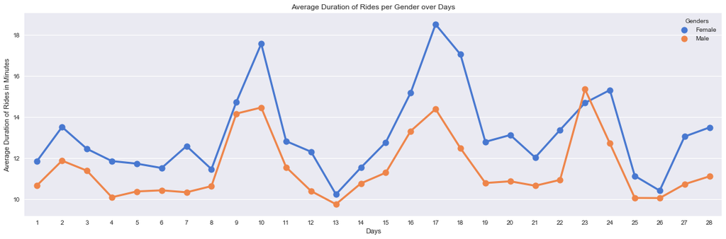

```python
#relation between gender and av rides duration over day
##create df
dfd = df2.groupby(['member_gender', 'days'])['duration_min'].mean().reset_index(name='dur')
#drop others (since its even missing data or users who decided not share the info)
dfd = dfd[dfd.member_gender!= "Other"]

##Plot
plt.figure(figsize = (20, 6))
plt.style.use('seaborn')
sb.pointplot(data = dfd.sort_values(by='days'), x = 'days', y = 'dur',
             hue = 'member_gender', palette = 'muted');
plt.legend(title = 'Genders');
plt.title('Average Duration of Rides per Gender over Days');
plt.xlabel('Days');
plt.ylabel('Average Duration of Rides in Minutes');
```

```python
#Numeric mean of duration grouped by gender
nmg = df2.groupby(['member_gender'])['duration_min'].mean()
nmg
```

```
member_gender
Female    12.981213
Male      11.206581
Other     18.845098
Name: duration_min, dtype: float64
```

While when comparing the average of trips for each gender, females took longer durations throughout the month with one exception on day 23 where the males exceeded with slight difference. Male trips averaged 11 minutes vs Female trips averaged 13 minutes

Eventhough Males have more tirps compared to females, the average duration for females was higher

```python
#Creat a new DF without others
dfothers = df2[df2.member_gender!= "Other"]
```

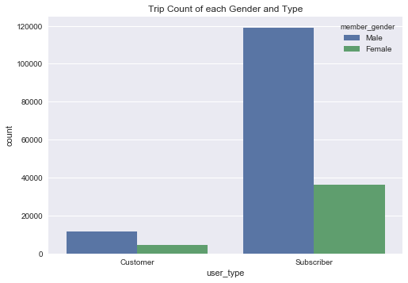

```python
#compare trip count of each gender and type
sb.countplot(data = dfothers,  x = 'user_type',hue = 'member_gender').set_title("Trip Count of each Gender and Type");
```

```python
#Numeric count of duration grouped by gender
c = dfothers.groupby(['member_gender','user_type'])['duration_sec'].count()
c
```

```
member_gender  user_type
Female         Customer        4623
               Subscriber     36182
Male           Customer       11493
               Subscriber    119007
Name: duration_sec, dtype: int64
```

```python
#relation between users and gender in terms of average duration
#create pivot table for av dur
table = pd.pivot_table(dfothers, values='duration_min', index=['user_type'],columns=['member_gender'], aggfunc=np.mean)
table
```

| member_gender user_type | Female | Male |
| --- | --- | --- |
| Customer | 23.735468 | 20.893225 |
| Subscriber | 11.607134 | 10.271101 |

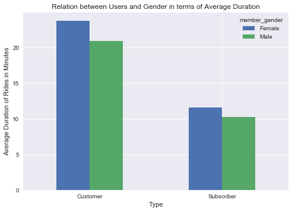

```python
#plot bar for av dur
table.plot(kind='bar')
plt.title('Relation between Users and Gender in terms of Average Duration');
plt.xlabel('Type');
plt.xticks(rotation=0)
plt.ylabel('Average Duration of Rides in Minutes');
```

Despite subscribers are the majority type; Customers show higher average duration in both Male and Female

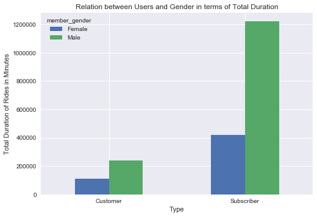

```python
#create pivot table for total duration
table1 = pd.pivot_table(dfothers, values='duration_min', index=['user_type'],columns=['member_gender'], aggfunc=np.sum)
table1.plot(kind='bar')
plt.title('Relation between Users and Gender in terms of Total Duration');
plt.xlabel('Type');
plt.xticks(rotation=0)
plt.ylabel('Total Duration of Rides in Minutes');
```

```python
#total dur numerics
table1
```

| member_gender user_type | Female | Male |
| --- | --- | --- |
| Customer | 109729.066667 | 2.401258e+05 |
| Subscriber | 419969.316667 | 1.222333e+06 |

The total duration is led by subscriber, Males significantly more than females. Same distribution with customers but with much less total duration compared to the subscribers